# R1. Model validation: decoy blueprints, external classifiers and architectural ablations

This notebook reproduces, from saved result files, every number that the manuscript quotes for

- **Experiment 1, decoy blueprint** (Results, "GeneSys reconstructs root developmental trajectories in silico"; Figure S6A and S6B),
- **Experiment 2, external validation of generated transcriptomes** (Figure S6C and S6D),
- **Experiment 3, ablation study** (Figure S6E and S6F).

Training and evaluation were run as cluster jobs with the scripts in `../codes/`. The commands are shown in each section but are not executed here. Each number is followed by an `assert`, so the notebook fails if a result file and the manuscript disagree.

| Claim in the manuscript | Section of this notebook |
| --- | --- |
| Recreation accuracy 84.4% (correct), 84.1% (reversed), 4.0% (shuffled), 15.1% (random) | 1.2 |
| Autoregressive generation accuracy 61.9%, 35.8%, 8.0%, 12.9%; correct and reversed differ by 26 points | 1.3 |
| Logistic regression reaches 96.8% on real held-out cells | 2.2 |
| Generated transcriptomes of the correct-blueprint model match their blueprint labels at 57.9% and 52.4% under the two external classifiers | 2.2 |
| Corrupted blueprints and ablations fall to between 10% and 15% | 2.3 |
| Reversed blueprint, nearest-centroid accuracy 42.7% to 21.2%; correct blueprint 63.5% to 49.9% | 2.4 |
| Ablation recreation accuracy 85% to 88% for variants trained on the correct blueprint; No LSTM 88% | 3.2 |
| Full model 59.6% (61.9% for the correct-blueprint model of Experiment 1); no TD-VAE 20.4% and no LSTM 17.5% | 3.3 |
| No blueprint: classification 10.1%, recreation 11.9%, generation 12.2%, all at chance | 3.4 |
| 13,918,579 parameters in the full model | 3.5 |

```python
import os, json
import numpy as np
import pandas as pd
from IPython.display import Image, display

R = os.path.join('..', 'results')                           # result files of the revision folder
pct = lambda x: round(100 * float(x), 1)                    # accuracy as a percentage with one decimal

# Figures are drawn by codes/exp24_manuscript_figures.py from the result tables in R
import importlib.util
os.environ['GENESYS_RESULTS'] = os.path.abspath(R)
os.environ['GENESYS_FIGURES'] = os.path.abspath(os.path.join(R, 'figures'))
_spec = importlib.util.spec_from_file_location('figures', os.path.join('..', 'codes', 'exp24_manuscript_figures.py'))
figures = importlib.util.module_from_spec(_spec)
_spec.loader.exec_module(figures)

def load_json(*parts):
    with open(os.path.join(R, *parts)) as fh:
        return json.load(fh)
```

## How the models of this notebook were trained

Every retrained model goes through the training function of the up-to-date GeneSys package, `run_cycle` in `genesys/genesys_cli.py`, called unchanged by `../codes/train_run_cycle.py`: one cycle of 30 epochs with the package defaults (AdamW, learning rate 1e-3, ReduceLROnPlateau with factor 0.5, patience 10 and threshold 0.05, gradient clipping at 5, best weights kept on lowest loss). Whatever an experiment varies enters through the inputs of `run_cycle` only:

- **labels** in the convention of the package, with time starting at 1 (`utils.load_root_data_blueprint`: the stem cells are time 1 and time bins 1 to 10 are times 2 to 11, as in `toy_data/annotations.txt`);
- **lineage blueprint table**: correct, reversed, shuffled or random. The reversed decoy combines the column-reversed table with time-reversed labels. The random table keeps the stem-cell column and draws one of the ten cell types at every later position;
- **model object**: noise level, width, a feedforward network in place of the LSTM, or the TD-VAE loss switched off. For the No TD-VAE ablation `calculate_loss` is replaced by a constant that is not connected to any parameter, so the steps that `run_cycle` assigns to the TD-VAE loss leave the model unchanged;
- **KL logging** is done by wrappers around `model.calculate_loss` and around the validation loader, not by editing the loop.

`../codes/check_blueprint_sequences.py` traces which cells each position of a sequence reads. With these inputs the correct blueprint reads the stem cell and then time bins 1 to 10, the same sequence as the `Root_Dataset` of the original notebooks, and the reversed decoy reads time bins 10 to 1 and then the stem cell.

All evaluations use the validation split, 10 batches of 512 trajectories.

## The three metrics used below

- **Classification accuracy.** Real cells are supplied at every time bin and the classifier predicts the trajectory at each bin (`evaluate_model` in `rescue_train_and_eval.py`). Stored in `*_eval_result.json`.
- **Recreation accuracy** (protocol of Figure S5; `eval_recreation_accuracy_v2.py`). To predict time bin *t*, real cells are supplied at every bin before *t* and the remaining positions repeat the last real cell. No transcriptome is generated. Stored in `*_recreation_acc_v2.json`.
- **Autoregressive generation accuracy** (`eval_recreation_accuracy.py`). The input holds real cells at t0, t1 and t2, with t2 repeated in the later positions. The model generates t0, t1 and t2 from this seed, and from t3 onward each bin is generated from a sequence that contains only generated transcriptomes. The classifier is read at every bin from t1 to t10. Stored in `*_recreation_acc.json`.

File naming note: the files named `*_recreation_acc.json` hold the autoregressive generation accuracy, and the files named `*_recreation_acc_v2.json` hold the recreation accuracy.

## 1. Experiment 1: decoy blueprint

Four models with the identical architecture are trained on the same data and differ only in the lineage blueprint used to assemble the training batches (lineage tables from `exp1_decoy_blueprint.py`, training through `rescue_train_and_eval.py` and `train_run_cycle.py`):

- **correct**: the root blueprint (10 trajectories by 11 time bins);
- **reversed**: every trajectory is read from t10 to t0 (column-reversed table read against time-reversed labels);
- **shuffled**: within each time bin, the cell type labels are permuted across trajectories;
- **random**: every position after the stem cell holds a cell type drawn at random.

All four models are then evaluated against the correct blueprint on the validation split.

```python
# Commands used on the cluster (not executed here).
# Training, one GPU job per blueprint (30 epochs through genesys_cli.run_cycle):
#   sbatch --job-name=rc_exp1_<blueprint> --gres=gpu:1 experiments/slurm/run_gpu_fast.sh \
#       experiments/rescue_train_and_eval.py --experiment=exp1 --condition=<correct|reversed|shuffled|random> --epochs 30
# Evaluation of every saved model (experiments/slurm/post_rc.sh):
#   python experiments/eval_recreation_accuracy_v2.py --experiment exp1 --condition <blueprint> --device cpu   # recreation accuracy
#   python experiments/eval_recreation_accuracy.py    --experiment exp1 --condition <blueprint> --device cpu   # autoregressive generation accuracy
#   python experiments/generate_sprint3_figures.py                                                             # summary table
#   python experiments/exp24_manuscript_figures.py                                                             # Figure S6
```

### 1.2 Recreation accuracy (Figure S6A and S6B)

```python
conds = ['correct', 'reversed', 'shuffled', 'random']
rec = {c: load_json('exp1_decoy', c, f'exp1_{c}_recreation_acc_v2.json') for c in conds}
recreation = pd.Series({c: pct(rec[c]['mean_acc']) for c in conds}, name='recreation accuracy (%)')
print(recreation.to_string())

assert recreation.to_dict() == {'correct': 84.4, 'reversed': 84.1, 'shuffled': 4.0, 'random': 15.1}

# the summary table of the decoy runs holds the same values
summary = pd.read_csv(os.path.join(R, 'exp1_decoy_summary.csv')).set_index('condition')
assert all(pct(summary.loc[c, 'mean_acc']) == recreation[c] for c in conds)
summary.round(3)
```

```
correct     84.4
reversed    84.1
shuffled     4.0
random      15.1
```

| condition | mean_acc | bin_1 | bin_2 | bin_3 | bin_4 | bin_5 | bin_6 | bin_7 | bin_8 | bin_9 | bin_10 |
| --- | --- | --- | --- | --- | --- | --- | --- | --- | --- | --- | --- |
| correct | 0.844 | 0.099 | 0.645 | 0.841 | 0.920 | 0.974 | 0.982 | 0.988 | 0.994 | 0.995 | 0.999 |
| reversed | 0.841 | 0.100 | 0.684 | 0.860 | 0.912 | 0.956 | 0.980 | 0.976 | 0.991 | 0.981 | 0.970 |
| shuffled | 0.040 | 0.104 | 0.062 | 0.036 | 0.021 | 0.025 | 0.043 | 0.031 | 0.039 | 0.024 | 0.010 |
| random | 0.151 | 0.100 | 0.142 | 0.192 | 0.186 | 0.159 | 0.149 | 0.146 | 0.145 | 0.154 | 0.142 |

### 1.3 Autoregressive generation accuracy (Figure S6A)

```python
gen = {c: load_json('exp1_decoy', c, f'exp1_{c}_recreation_acc.json') for c in conds}
generation = pd.Series({c: pct(gen[c]['mean_acc']) for c in conds}, name='generation accuracy (%)')
print(pd.concat([recreation, generation], axis=1).to_string())

assert generation.to_dict() == {'correct': 61.9, 'reversed': 35.8, 'shuffled': 8.0, 'random': 12.9}

# "autoregressive generation separates them by 26 percentage points" (legend of Figure S6)
gap = round(generation['correct'] - generation['reversed'], 1)
print('correct minus reversed:', gap, 'percentage points')
assert round(gap) == 26
# each model is scored on 5,120 trajectories per time bin
assert set(gen['correct']['n_samples_per_bin'].values()) == {5120}
```

```
          recreation accuracy (%)  generation accuracy (%)
correct                      84.4                     61.9
reversed                     84.1                     35.8
shuffled                      4.0                      8.0
random                       15.1                     12.9
correct minus reversed: 26.1 percentage points
```

## 2. Experiment 2: external validation of generated transcriptomes

The accuracies above come from the classifier of the same model that generated the cells. `exp12_external_scoring.py` scores the generated transcriptomes with two classifiers fitted on real cells only:

- a **multinomial logistic regression** (scikit-learn, 1,000 iterations, default L2 penalty) fitted on 20,000 cells drawn at random from the training split, with cell type as the label, and checked on 5,000 real cells of the validation split;
- a **nearest-centroid classifier**: for each cell type and time bin the mean transcriptome of the real training cells is computed, and a generated transcriptome at time bin *t* is assigned to the cell type whose centroid at *t* has the highest cosine similarity to it.

Transcriptomes are generated with the autoregressive protocol described above for the published model, the four decoy models and the four ablation models, and scored against the blueprint label at each of the generated time bins t2 to t10.

```python
# Command used on the cluster (not executed here):
#   python experiments/exp12_external_scoring.py --device cpu        (part of experiments/slurm/post_rc.sh)
```

### 2.2 The correct-blueprint model under the two external classifiers

```python
ext = pd.read_csv(os.path.join(R, 'exp12_external', 'exp12_external_summary.csv')).set_index('model')
scores = pd.read_csv(os.path.join(R, 'exp12_external', 'exp12_external_scores.csv'))

lr_on_real = pct(scores['lr_reference_acc_on_real'].iloc[0])
print('logistic regression on real held-out cells:', lr_on_real, '%')
assert lr_on_real == 96.8 and scores['lr_reference_acc_on_real'].nunique() == 1

correct = ext.loc['exp1_correct']
print('correct-blueprint model: logistic regression', pct(correct['lr_acc']), '% ; nearest centroid', pct(correct['centroid_acc']), '%')
assert pct(correct['lr_acc']) == 57.9 and pct(correct['centroid_acc']) == 52.4
(ext[['lr_acc', 'centroid_acc']] * 100).round(1)
```

```
logistic regression on real held-out cells: 96.8 %
correct-blueprint model: logistic regression 57.9 % ; nearest centroid 52.4 %
```

| model | lr_acc | centroid_acc |
| --- | --- | --- |
| exp1_correct | 57.9 | 52.4 |
| exp1_random | 11.2 | 11.0 |
| exp1_reversed | 21.3 | 26.0 |
| exp1_shuffled | 11.8 | 11.4 |
| exp6_full | 54.9 | 55.2 |
| exp6_no_blueprint | 14.7 | 14.9 |
| exp6_no_lstm | 9.8 | 9.7 |
| exp6_no_tdvae | 10.5 | 9.8 |
| published_600ep | 69.9 | 58.9 |

### 2.3 Corrupted blueprints and ablations (Figure S6C)

```python
collapsed = ['exp1_shuffled', 'exp1_random', 'exp6_no_tdvae', 'exp6_no_lstm', 'exp6_no_blueprint']
tab = (ext.loc[collapsed, ['lr_acc', 'centroid_acc']] * 100).round(1)
print(tab.to_string())
# "fell to between 10% and 15%": every value lies between 9.7% and 14.9%
assert tab.values.min() >= 9.5 and tab.values.max() <= 15

# the reversed-blueprint model lies between the correct-blueprint model and the collapsed models
for col in ['lr_acc', 'centroid_acc']:
    assert ext.loc[collapsed, col].max() < ext.loc['exp1_reversed', col] < ext.loc['exp1_correct', col]
print('reversed blueprint: logistic regression', pct(ext.loc['exp1_reversed', 'lr_acc']), '% ; nearest centroid',
      pct(ext.loc['exp1_reversed', 'centroid_acc']), '%')
```

```
                   lr_acc  centroid_acc
model
exp1_shuffled        11.8          11.4
exp1_random          11.2          11.0
exp6_no_tdvae        10.5           9.8
exp6_no_lstm          9.8           9.7
exp6_no_blueprint    14.7          14.9
reversed blueprint: logistic regression 21.3 % ; nearest centroid 26.0 %
```

### 2.4 Nearest-centroid accuracy along the generated trajectory (Figure S6D)

```python
per_bin = (scores[scores['model'].isin(['exp1_correct', 'exp1_reversed'])]
           .pivot(index='time_bin', columns='model', values='centroid_acc') * 100).round(1)
print(per_bin.to_string())

assert list(per_bin.index) == [2, 3, 4, 5, 6, 7, 8, 9, 10]        # generated bins that are scored
assert (per_bin['exp1_reversed'].iloc[0], per_bin['exp1_reversed'].iloc[-1]) == (42.7, 21.2)
assert (per_bin['exp1_correct'].iloc[0], per_bin['exp1_correct'].iloc[-1]) == (63.5, 49.9)
```

```
model     exp1_correct  exp1_reversed
time_bin
2                 63.5           42.7
3                 54.0           30.4
4                 52.9           25.8
5                 51.1           24.7
6                 50.3           23.9
7                 49.9           22.4
8                 49.2           21.8
9                 50.6           21.6
10                49.9           21.2
```

## 3. Experiment 3: ablation study

Four variants are trained from scratch (model classes from `exp6_ablation.py`, training through `rescue_train_and_eval.py` and `train_run_cycle.py`):

- **full**: the standard model (bidirectional LSTM, TD-VAE, correct blueprint), trained with the alternating loss;
- **no_tdvae**: the TD-VAE loss is switched off (`calculate_loss` returns a constant that is not connected to any parameter), so only the classifier loss trains the model;
- **no_lstm**: the bidirectional LSTM is replaced by a feedforward network that processes each time bin independently;
- **no_blueprint**: trained on a blueprint with a random cell type at each position after the stem cell.

Each variant is evaluated with the correct blueprint on the validation split by the three metrics.

```python
# Commands used on the cluster (not executed here):
#   sbatch --job-name=rc_exp6_<variant> --gres=gpu:1 experiments/slurm/run_gpu_fast.sh \
#       experiments/rescue_train_and_eval.py --experiment=exp6 --condition=<full|no_tdvae|no_lstm|no_blueprint> --epochs 30
#   python experiments/eval_recreation_accuracy_v2.py --experiment exp6 --condition <variant> --device cpu
#   python experiments/eval_recreation_accuracy.py    --experiment exp6 --condition <variant> --device cpu
```

```python
variants = ['full', 'no_tdvae', 'no_lstm', 'no_blueprint']
abl = pd.DataFrame({
    'classification (%)': {v: 100 * load_json('exp6_ablation', v, f'exp6_{v}_eval_result.json')['mean_acc_correct_bp'] for v in variants},
    'recreation (%)':     {v: 100 * load_json('exp6_ablation', v, f'exp6_{v}_recreation_acc_v2.json')['mean_acc'] for v in variants},
    'generation (%)':     {v: 100 * load_json('exp6_ablation', v, f'exp6_{v}_recreation_acc.json')['mean_acc'] for v in variants},
})
abl.round(2)
```

|  | classification (%) | recreation (%) | generation (%) |
| --- | --- | --- | --- |
| full | 100.00 | 84.87 | 59.57 |
| no_tdvae | 100.00 | 86.03 | 20.38 |
| no_lstm | 88.69 | 87.88 | 17.46 |
| no_blueprint | 10.11 | 11.87 | 12.20 |

### 3.2 Recreation accuracy does not separate the variants trained on the correct blueprint

```python
r = abl.loc[['full', 'no_tdvae', 'no_lstm'], 'recreation (%)']
print(r.round(1).to_string())
assert 84.5 <= r.min() and r.max() <= 88.5          # "between 85% and 88%"
assert round(r['no_lstm']) == 88                    # "even the No LSTM variant ... reached 88%"
```

```
full        84.9
no_tdvae    86.0
no_lstm     87.9
```

### 3.3 Autoregressive generation separates them

```python
g = abl['generation (%)'].round(1)
print(g.to_string())
assert g['full'] == 59.6
assert (g['no_tdvae'], g['no_lstm']) == (20.4, 17.5)
# the full model and the correct-blueprint model of Experiment 1 are independent runs of the same configuration
print('full model', g['full'], '% ; correct-blueprint model of Experiment 1', generation['correct'], '%')
assert generation['correct'] == 61.9
```

```
full            59.6
no_tdvae        20.4
no_lstm         17.5
no_blueprint    12.2
full model 59.6 % ; correct-blueprint model of Experiment 1 61.9 %
```

### 3.4 The model trained without the blueprint

```python
nb = abl.loc['no_blueprint']
print(nb.round(2).to_string())
assert round(nb['classification (%)'], 1) == 10.1
assert round(nb['recreation (%)'], 1) == 11.9
assert round(nb['generation (%)'], 1) == 12.2
assert (nb.between(9, 13)).all()                      # all three at the chance level of 10%
```

```
classification (%)    10.11
recreation (%)        11.87
generation (%)        12.20
```

### 3.5 Size of the full model

```python
sweep = pd.read_csv(os.path.join(R, 'exp10_latent_sweep_summary.csv')).set_index('dim')
print('parameters of the model at width 256:', f"{int(sweep.loc[256, 'n_params']):,}")
assert int(sweep.loc[256, 'n_params']) == 13918579
```

```
parameters of the model at width 256: 13,918,579
```

```
  saved figS_blueprint_controls.pdf / .png / .tif  (5.93 x 4.46 in at 600 dpi)
```

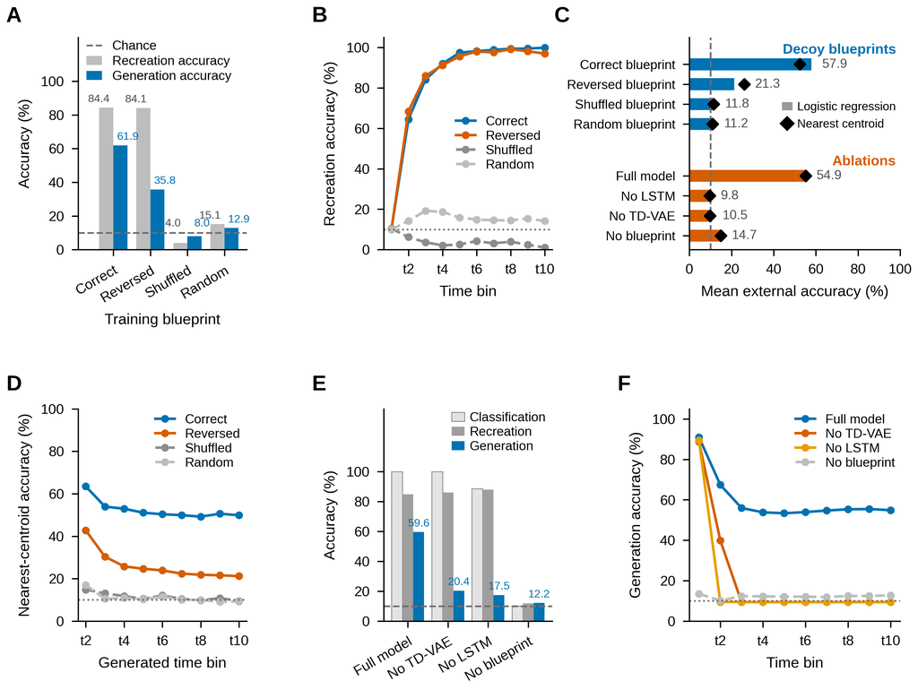

```python
figures.figure_blueprint_controls()   # Figure S6, drawn from the tables above
display(Image(os.path.join(R, 'figures', 'figS_blueprint_controls.png'), width=900))
```